# Red Wine Quality Exploratory Data Analysis by Dylan Rose

> In this report, I will be exploring a dataset that contains review data for 1,599 red wine varieties. The dataset includes several chemical and physical properties, as well as the final overall quality assessment for each wine.

## # Univariate Plots Section

> There are 13 variables with about 1,600 observations in our dataset. Each observation is from a different wine variety.

```
## 'data.frame':    1599 obs. of  13 variables:
##  $ X                   : int  1 2 3 4 5 6 7 8 9 10 ...
##  $ fixed.acidity       : num  7.4 7.8 7.8 11.2 7.4 7.4 7.9 7.3 7.8 7.5 ...
##  $ volatile.acidity    : num  0.7 0.88 0.76 0.28 0.7 0.66 0.6 0.65 0.58 0.5 ...
##  $ citric.acid         : num  0 0 0.04 0.56 0 0 0.06 0 0.02 0.36 ...
##  $ residual.sugar      : num  1.9 2.6 2.3 1.9 1.9 1.8 1.6 1.2 2 6.1 ...
##  $ chlorides           : num  0.076 0.098 0.092 0.075 0.076 0.075 0.069 0.065 0.073 0.071 ...
##  $ free.sulfur.dioxide : num  11 25 15 17 11 13 15 15 9 17 ...
##  $ total.sulfur.dioxide: num  34 67 54 60 34 40 59 21 18 102 ...
##  $ density             : num  0.998 0.997 0.997 0.998 0.998 ...
##  $ pH                  : num  3.51 3.2 3.26 3.16 3.51 3.51 3.3 3.39 3.36 3.35 ...
##  $ sulphates           : num  0.56 0.68 0.65 0.58 0.56 0.56 0.46 0.47 0.57 0.8 ...
##  $ alcohol             : num  9.4 9.8 9.8 9.8 9.4 9.4 9.4 10 9.5 10.5 ...
##  $ quality             : int  5 5 5 6 5 5 5 7 7 5 ...
```

```
##        X          fixed.acidity   volatile.acidity  citric.acid
##  Min.   :   1.0   Min.   : 4.60   Min.   :0.1200   Min.   :0.000
##  1st Qu.: 400.5   1st Qu.: 7.10   1st Qu.:0.3900   1st Qu.:0.090
##  Median : 800.0   Median : 7.90   Median :0.5200   Median :0.260
##  Mean   : 800.0   Mean   : 8.32   Mean   :0.5278   Mean   :0.271
##  3rd Qu.:1199.5   3rd Qu.: 9.20   3rd Qu.:0.6400   3rd Qu.:0.420
##  Max.   :1599.0   Max.   :15.90   Max.   :1.5800   Max.   :1.000
##  residual.sugar     chlorides       free.sulfur.dioxide total.sulfur.dioxide
##  Min.   : 0.900   Min.   :0.01200   Min.   : 1.00       Min.   :  6.00
##  1st Qu.: 1.900   1st Qu.:0.07000   1st Qu.: 7.00       1st Qu.: 22.00
##  Median : 2.200   Median :0.07900   Median :14.00       Median : 38.00
##  Mean   : 2.539   Mean   :0.08747   Mean   :15.87       Mean   : 46.47
##  3rd Qu.: 2.600   3rd Qu.:0.09000   3rd Qu.:21.00       3rd Qu.: 62.00
##  Max.   :15.500   Max.   :0.61100   Max.   :72.00       Max.   :289.00
##     density             pH          sulphates         alcohol
##  Min.   :0.9901   Min.   :2.740   Min.   :0.3300   Min.   : 8.40
##  1st Qu.:0.9956   1st Qu.:3.210   1st Qu.:0.5500   1st Qu.: 9.50
##  Median :0.9968   Median :3.310   Median :0.6200   Median :10.20
##  Mean   :0.9967   Mean   :3.311   Mean   :0.6581   Mean   :10.42
##  3rd Qu.:0.9978   3rd Qu.:3.400   3rd Qu.:0.7300   3rd Qu.:11.10
##  Max.   :1.0037   Max.   :4.010   Max.   :2.0000   Max.   :14.90
##     quality
##  Min.   :3.000
##  1st Qu.:5.000
##  Median :6.000
##  Mean   :5.636
##  3rd Qu.:6.000
##  Max.   :8.000
```

> First, I’d like to get an overall idea of the quality of the wines in the dataset:

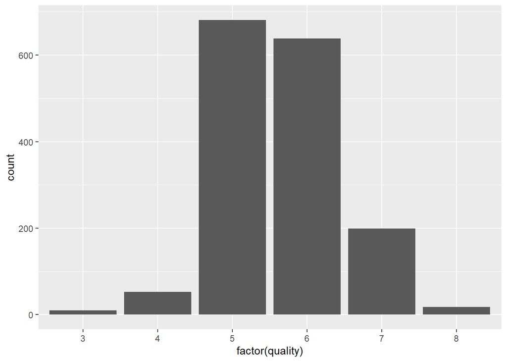

> The minimum quality is 3, and the maximum is 8. The units of measurement are discrete integers, which makes categorization a bit easier. The average qualities are 5s and 6s, which is unsurprising. I wonder if there are any specific qualities that are common in middling wines that reults in such “average” ratings.

> As I have no wine-tasting experience, I would also like to tease out which specific qualities are common for a score of 8. I believe I will explore this in the bivariate section.

### Acidity

> There are four separate variables specifically for acidity, so I imagine this is a very important factor in wine quality assessment.

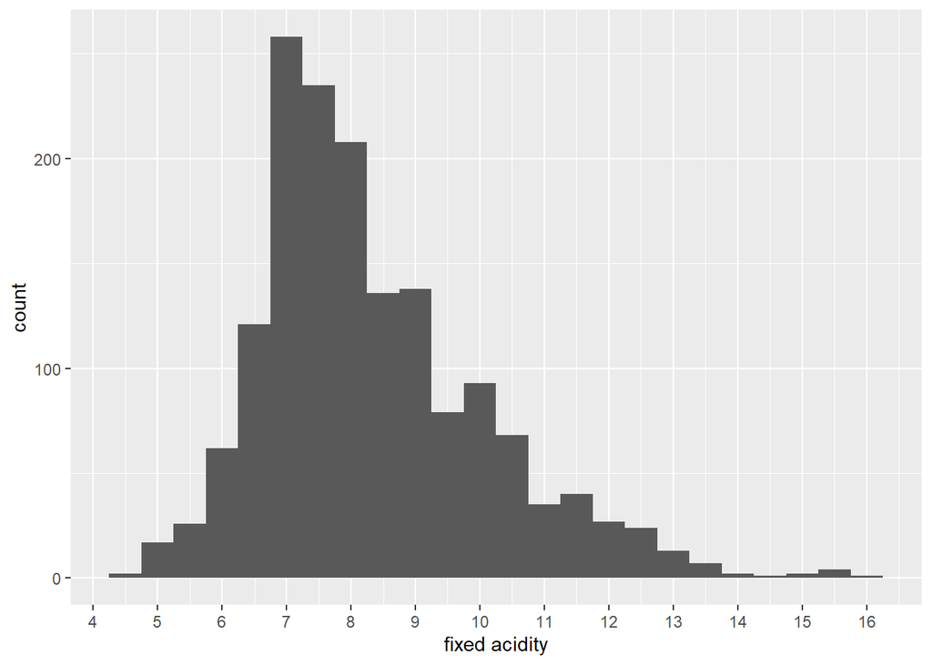

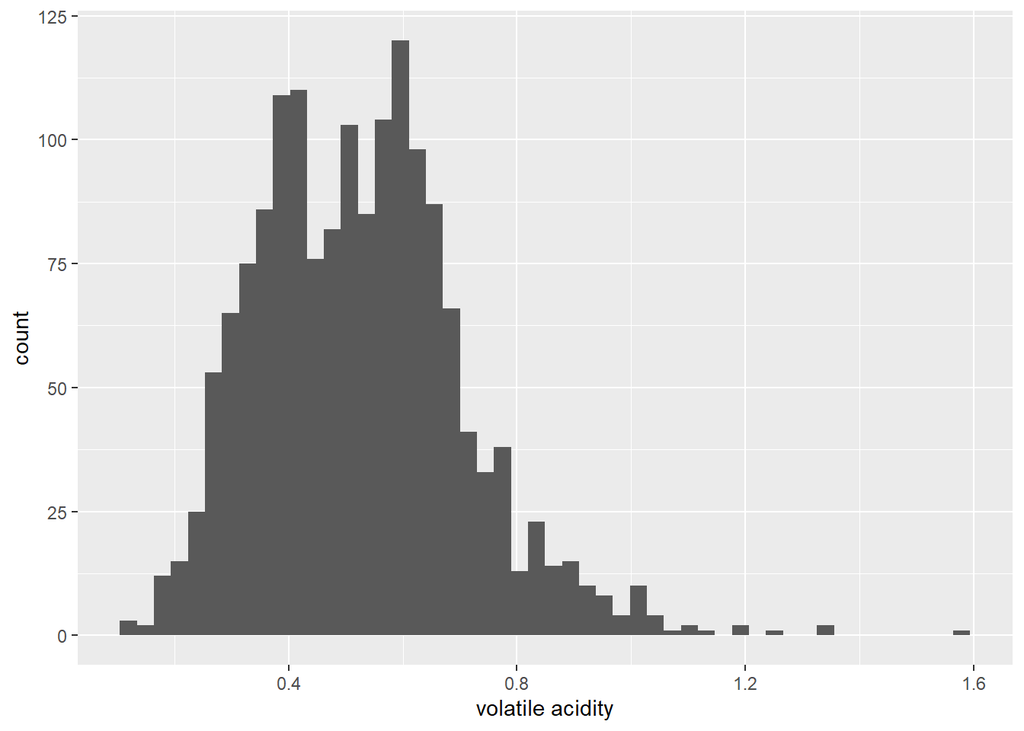

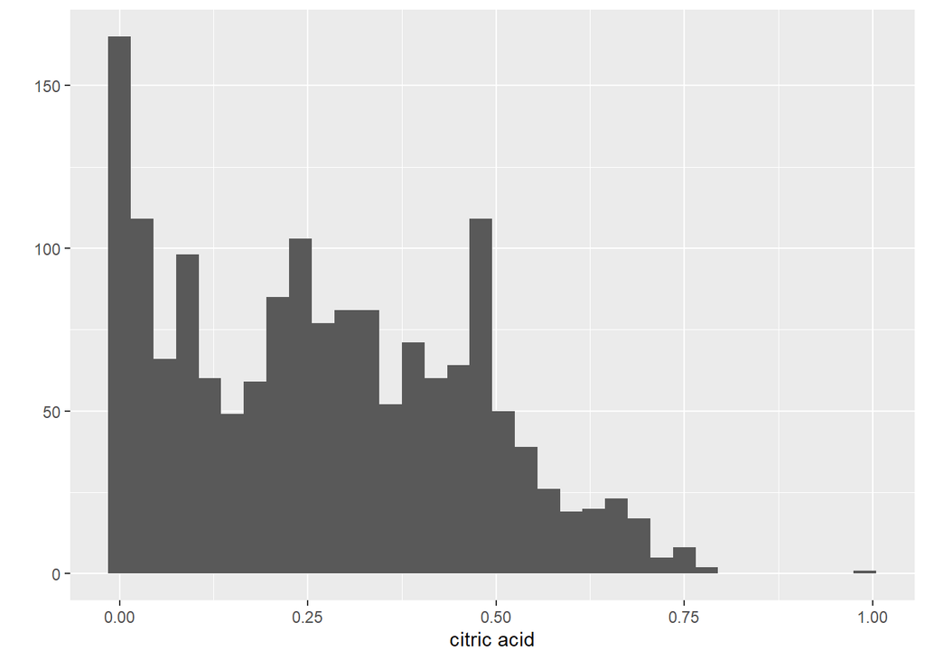

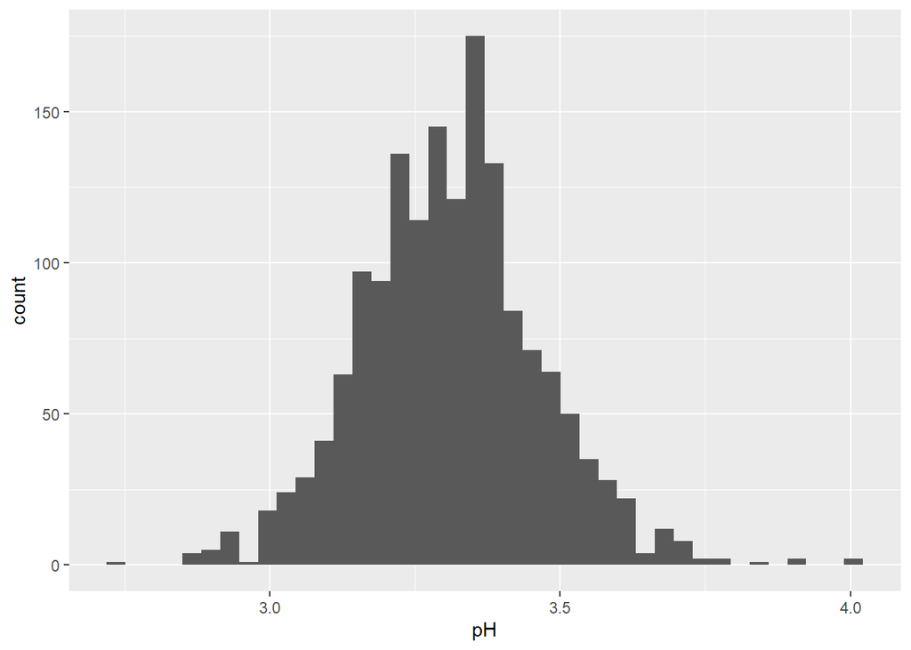

```
##
##  Fixed Acidity :
##    Min. 1st Qu.  Median    Mean 3rd Qu.    Max.
##    4.60    7.10    7.90    8.32    9.20   15.90
##  Standard Deviation:  1.7410963181277
```

```
##
##  Volatile Acidity :
##    Min. 1st Qu.  Median    Mean 3rd Qu.    Max.
##  0.1200  0.3900  0.5200  0.5278  0.6400  1.5800
##  Standard Deviation:  0.179059704153535
```

```
##
##  Citric Acid :
##    Min. 1st Qu.  Median    Mean 3rd Qu.    Max.
##   0.000   0.090   0.260   0.271   0.420   1.000
##  Standard Deviation:  0.194801137405319
```

```
##
##  pH :
##    Min. 1st Qu.  Median    Mean 3rd Qu.    Max.
##   2.740   3.210   3.310   3.311   3.400   4.010
##  Standard Deviation:  0.154386464903543
```

> It would appear that all wines tasted are acidic. There is at least one observation in both the volatile acidity and citric acid variables that are far above the rest, while one observation in the pH scale is unusually low. I wonder if these are all from the same highly acidic wine.

> From the description of volatile acidity, this wine would have a high amount of acetic acid. I wonder if it had spoiled and turned to vinegar.

> Most wines seem to have a lower amount of citric acid, and the majority of have a volatile acidity greater than 0.3 and less than 0.8.

> The mean pH of the wines is 3.3.

### Sweetness & Saltiness

> There are variables for residual sugars and chlorides, which respectively influence the sweetness and saltiness of the wine.

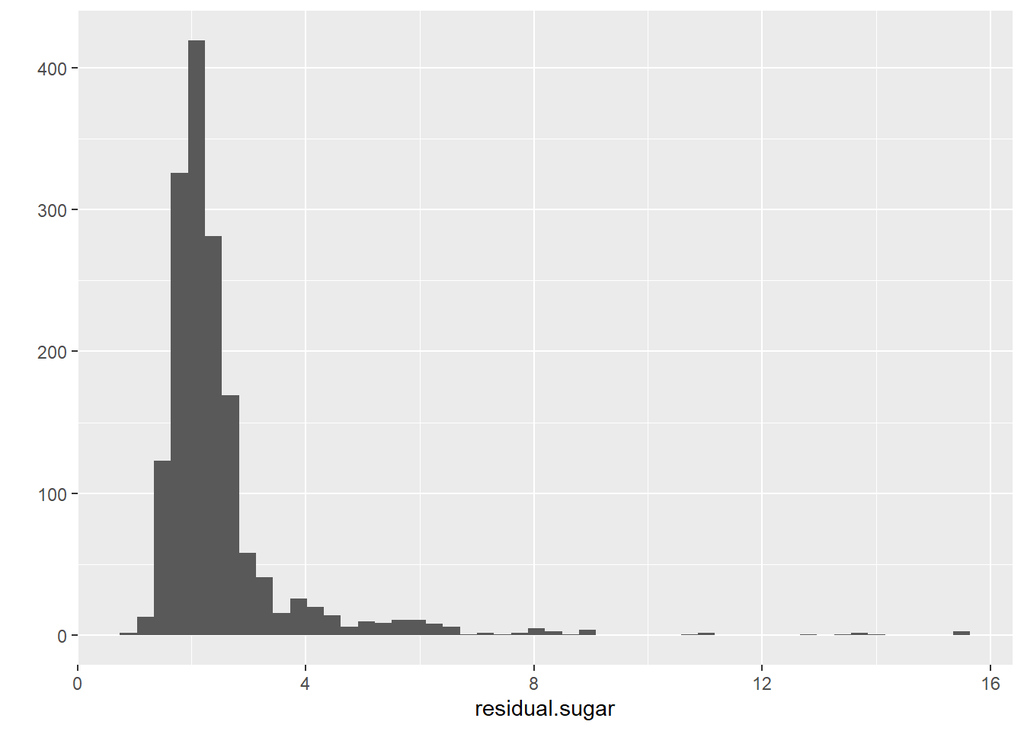

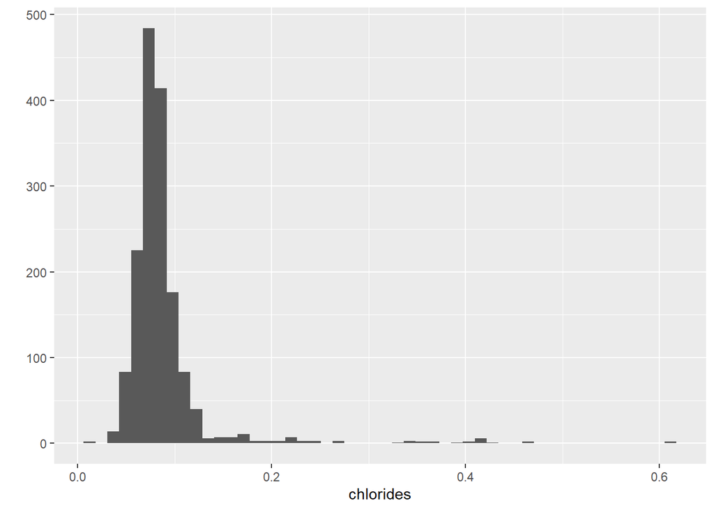

```
##
##  Residual Sugar :
##    Min. 1st Qu.  Median    Mean 3rd Qu.    Max.
##   0.900   1.900   2.200   2.539   2.600  15.500
##  Standard Deviation:  1.40992805950728
```

```
##
##  Chlorides :
##    Min. 1st Qu.  Median    Mean 3rd Qu.    Max.
## 0.01200 0.07000 0.07900 0.08747 0.09000 0.61100
##  Standard Deviation:  0.0470653020100901
```

> Most wines seem to have lower quantities of residual sugars and chlorides, while the long tails of each variable indicates some very sweet and very salty wines are sprinkled throughout the sample.

### Sulfur Dioxide

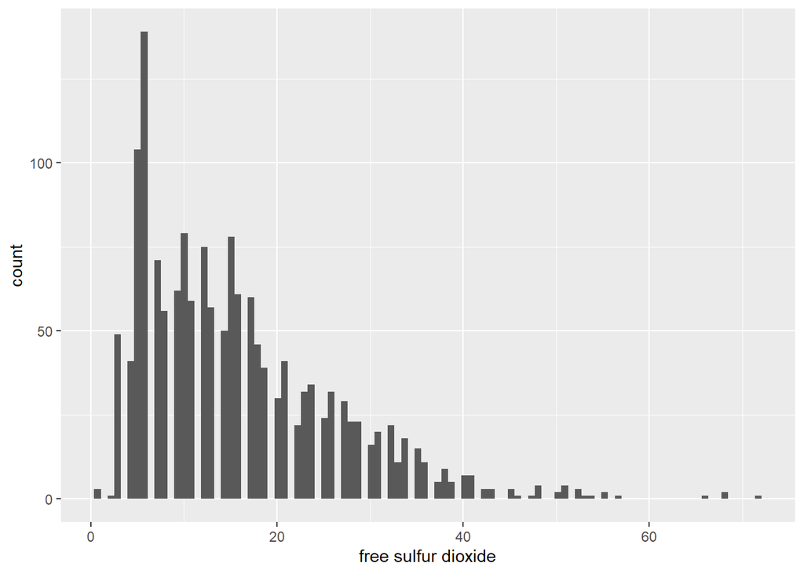

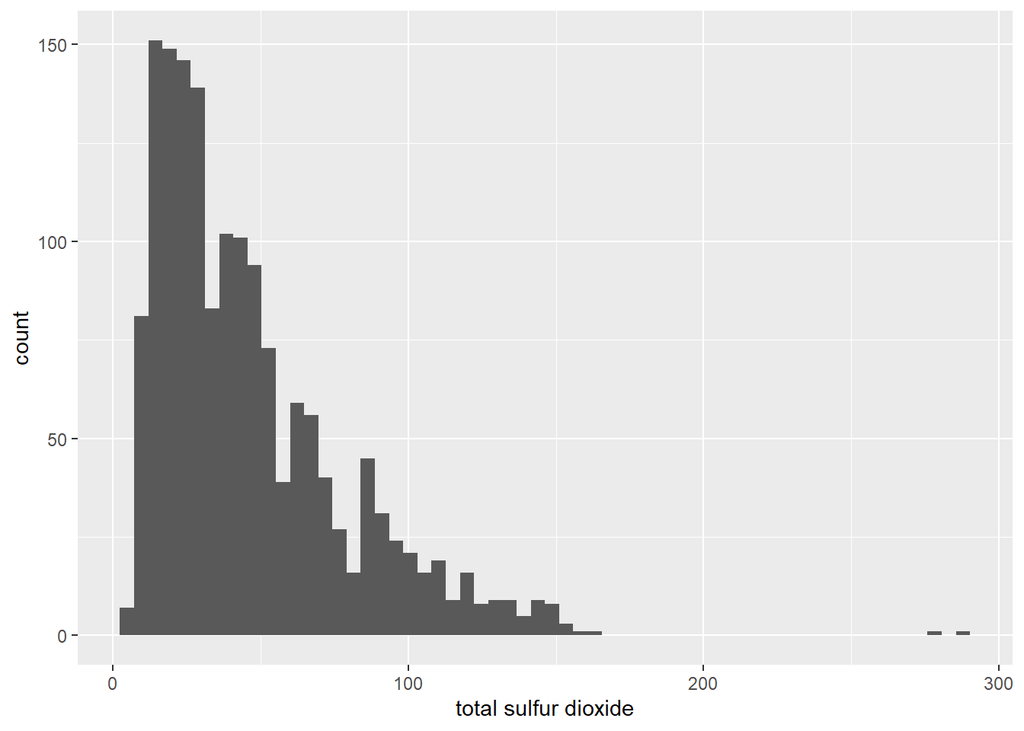

```
##
##  Free Sulfur Dioxide :
##    Min. 1st Qu.  Median    Mean 3rd Qu.    Max.
##    1.00    7.00   14.00   15.87   21.00   72.00
##  Standard Deviation:  10.4601569698097
```

```
##
##  Total Sulfur Dioxide :
##    Min. 1st Qu.  Median    Mean 3rd Qu.    Max.
##    6.00   22.00   38.00   46.47   62.00  289.00
##  Standard Deviation:  32.8953244782991
```

> The free sulfur dioxide and total sulfur dioxide histograms are closely mirrored. The description of these variables indicates that they will minimally affect taste, but may affect the shelf stability and aging processes of the wines. Most wines seem to have relatively similar levels of sulfur dioxide.

> This chart shows regular gaps in the sulfur dioxide ratings. I wonder if this is indicative of the use of rounding values, or if there is something physical going on here.

### Density

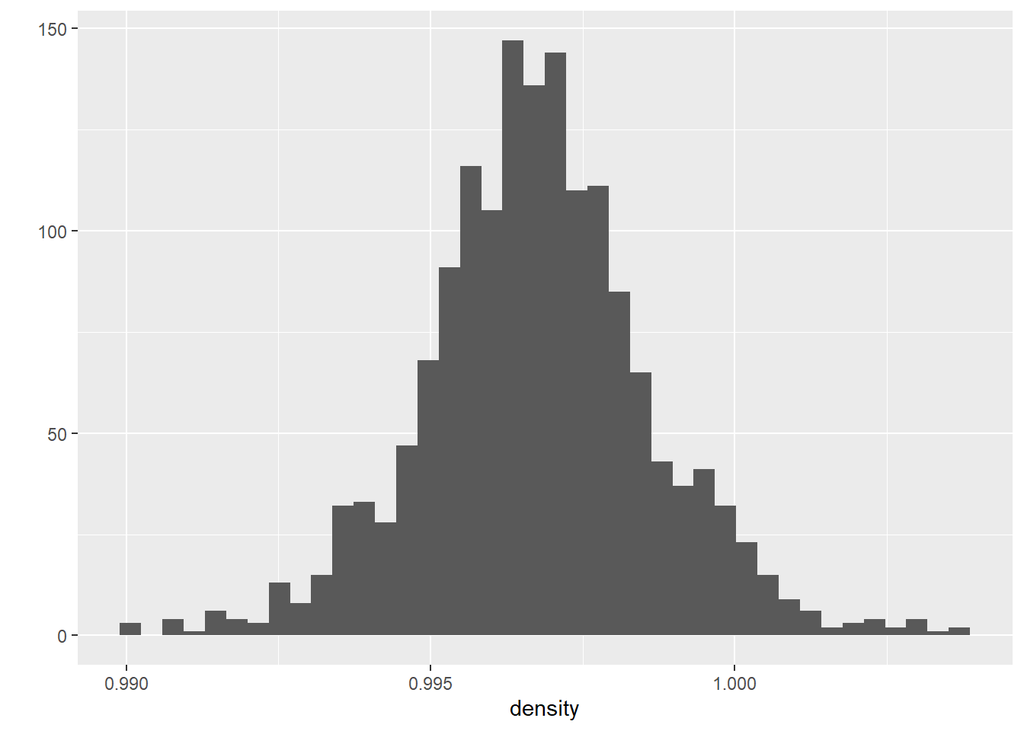

```
##
##  Density :
##    Min. 1st Qu.  Median    Mean 3rd Qu.    Max.
##  0.9901  0.9956  0.9968  0.9967  0.9978  1.0037
##  Standard Deviation:  0.00188733395384256
```

> While there is very little variance on density, it can be noted that the majority of wines are less dense than water, with very few having a higher density than water. As sugar is more dense than water, and alcohol is less dense than water, I wonder if the density of a wine is a good predictor if the levels of its sugar and alcohol.

### Sulphates

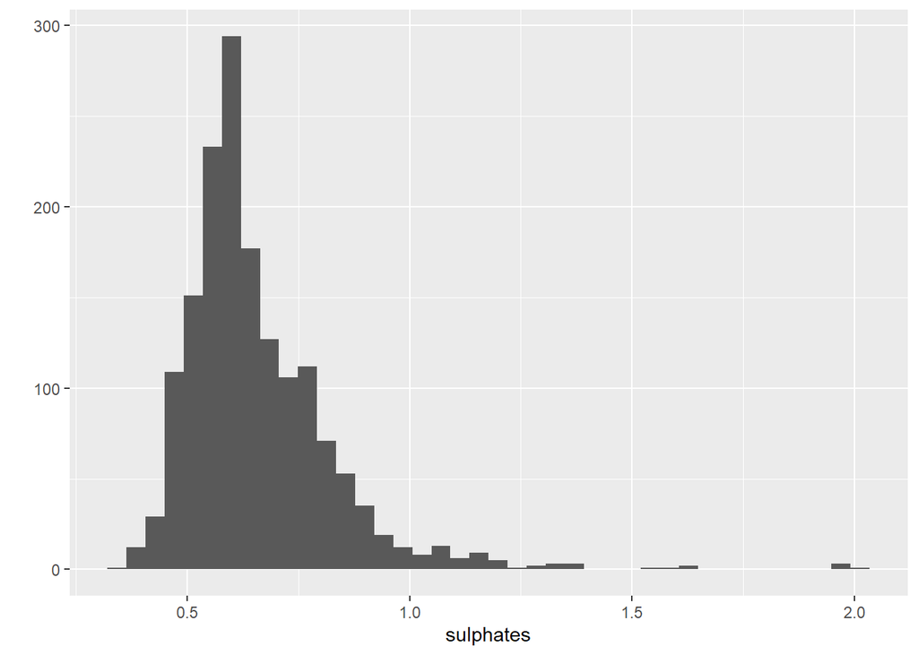

```
##
##  Sulphates :
##    Min. 1st Qu.  Median    Mean 3rd Qu.    Max.
##  0.3300  0.5500  0.6200  0.6581  0.7300  2.0000
##  Standard Deviation:  0.16950697959011
```

> I’m not sure what to do with this data, but I do wonder how it affects the quality rating of wines, since it is listed as being used as an antimicrobial and antioxidant. Perhaps wines with lower levels of sulphates will have lower scores, as they may have slightly spoiled.

### Alcohol

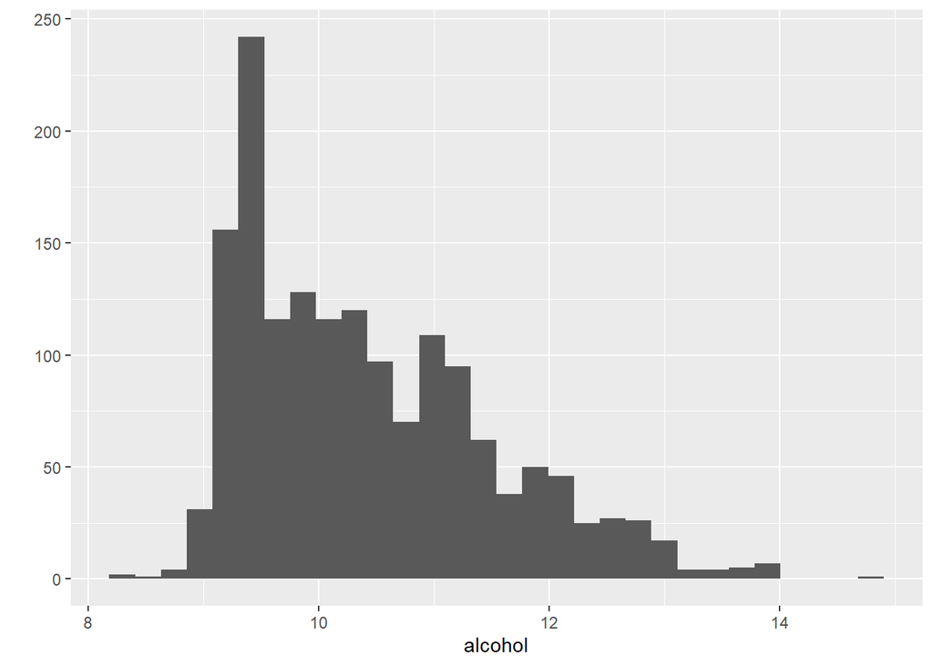

```
##
##  Alcohol :
##    Min. 1st Qu.  Median    Mean 3rd Qu.    Max.
##    8.40    9.50   10.20   10.42   11.10   14.90
##  Standard Deviation:  1.06566758184739
```

> Most of the wines seem to fall between 9% and 12% abv, although there are some very strong wines in this list.

# Univariate Analysis

### What is the structure of your dataset?

Other Observations:

- Most wines have a quality rating of 5 or 6. This may indicate that there must necessarily be either a very pleasant or very unpleasant factor experienced in order to gain higher or lower rankings.
- The pH and density variables both seem to have fairly normal distributions.
- All other factors, namely: alcohol, sulphates, total sulfur dioxide, free sulfur dioxide, chlorides, residual sugar, and the acidity factors - all have significant positively skewed distributions.
- The mean quality rating is ~5.636.

### What is/are the main feature(s) of interest in your dataset?

> The main feature of interest in this dataset is the quality ranking of the wines. I would like to find out which variables can be used to reliably predict the quality of a wine. In particular, I would like to see which qualities can maximimize the perceived quality of a wine.

### What other features in the dataset do you think will help support your investigation into your feature(s) of interest?

> I believe residual sugars, acidity factors (particularly pH), chlorides, alcohol, and density will all be helpful to analyze. These factors are the biggest contributors to flavor (sweetness, sourness, saltiness, “booziness,” and mouthfeel. )

### Did you create any new variables from existing variables in the dataset?

> I did not create any new variables in this dataset. These values are generally very straightforward, and I feel that I will tease out the most interesting relationships in this data in the bivariate analysis.

### Of the features you investigated, were there any unusual distributions? Did you perform any operations on the data to tidy, adjust, or change the form of the data? If so, why did you do this?

> There were some very highly acidic outliers in the data. This is unusual, and I assume this is indicative of a wine that has turned to vinegar or otherwise gone bad. The residual sugar and chloride distributions were also very positively skewed with very long tails.

> The only operations I performed were adjusting the scale and bins of a few of the histograms. I did this to better tease out a useful representation of the distributions.

# Bivariate Plots Section

## Feature-Quality relationships

### Alcohol-Quality relationships

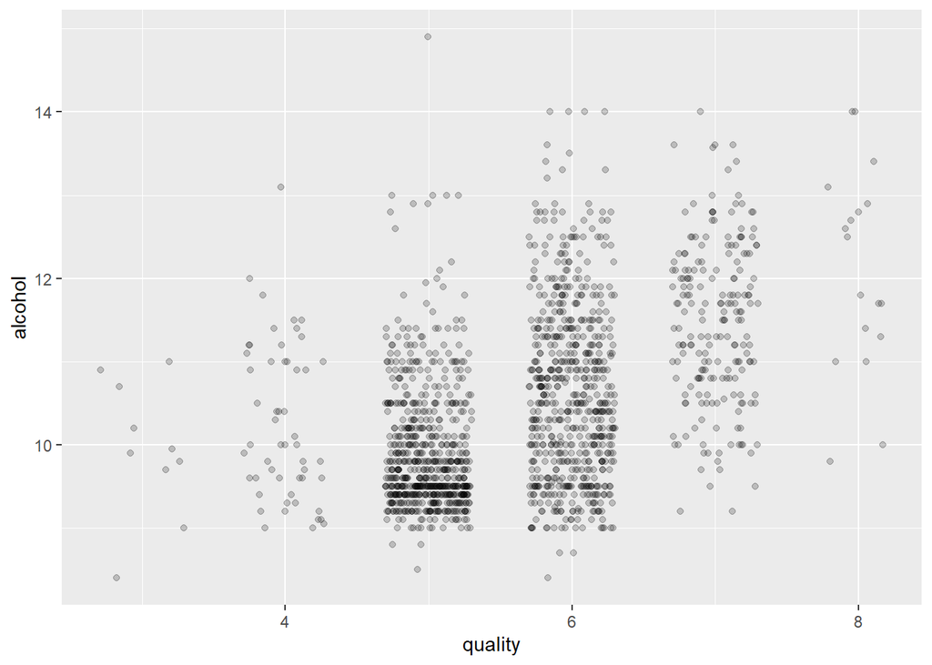

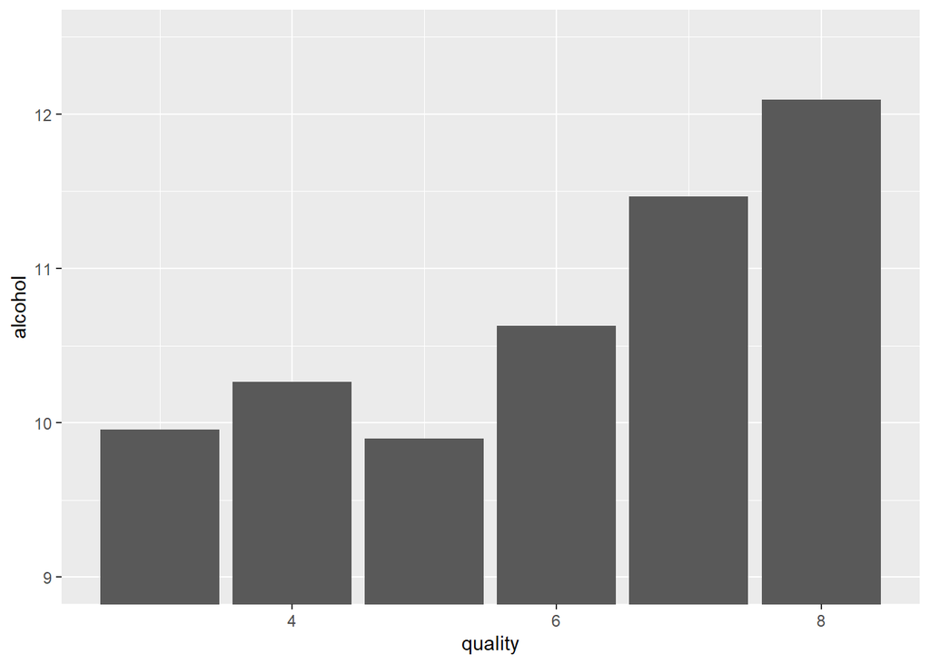

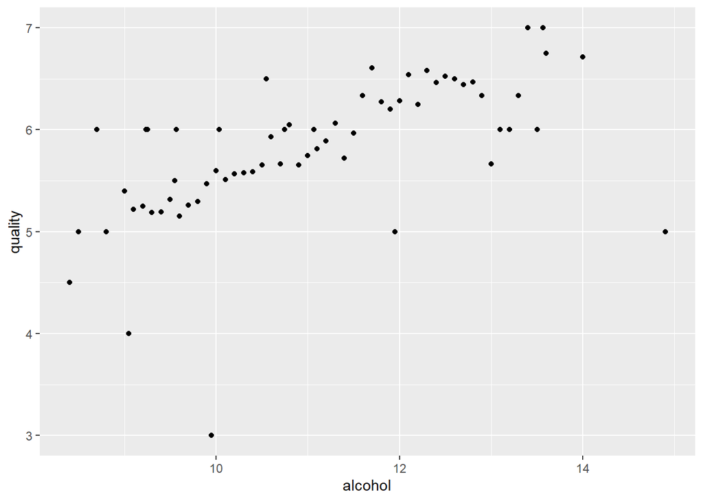

```
## Alcohol - Quality correlation:  0.476166324001136
```

> Alcohol and quality are strongly positive correlated, with a correlation of *~0.48*! We can see that stronger wines, on average, receive a higher rating. We can also see that, at the extremes, the highest rated wines are stronger.

### Residual Sugar-Quality relationships

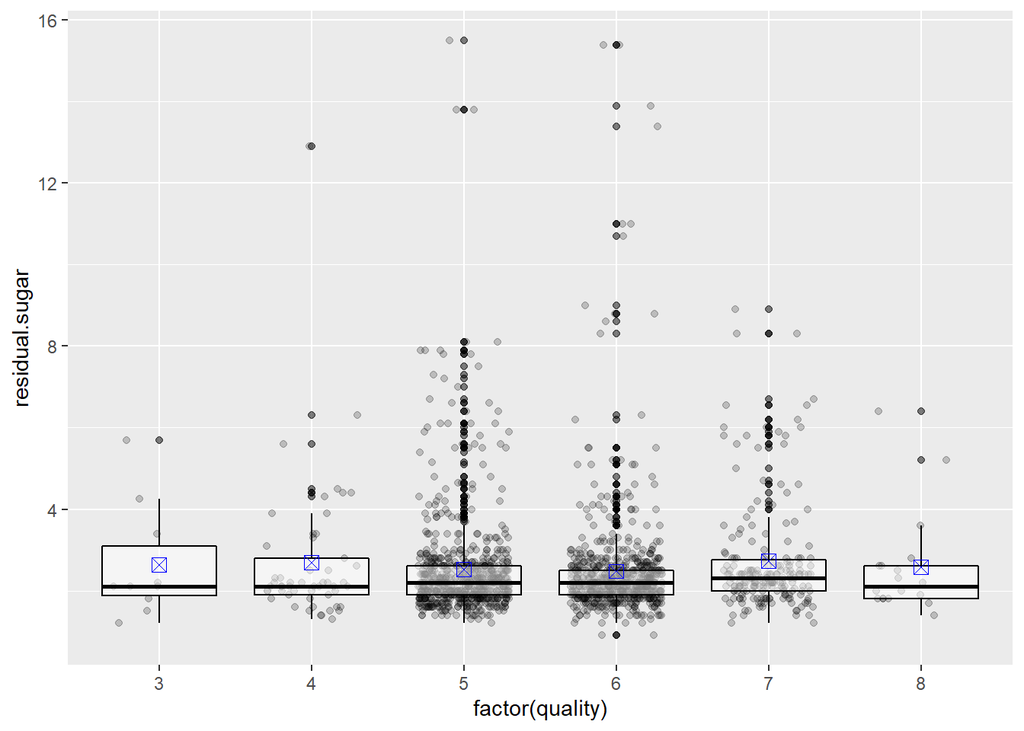

```
## Residual Sugar - Quality correlation:  0.0137316373400663
```

> I have chosen this plot to identify if there is a relationship between the residual sugar in a wine and its quality. I suspected that it may, as the sweetness of a wine will be expected to affect an individual’s preference.

> Residual sugar only has a correlation with quality of ~0.014. This is a very weak relationship

### Sulphates-Quality relationships

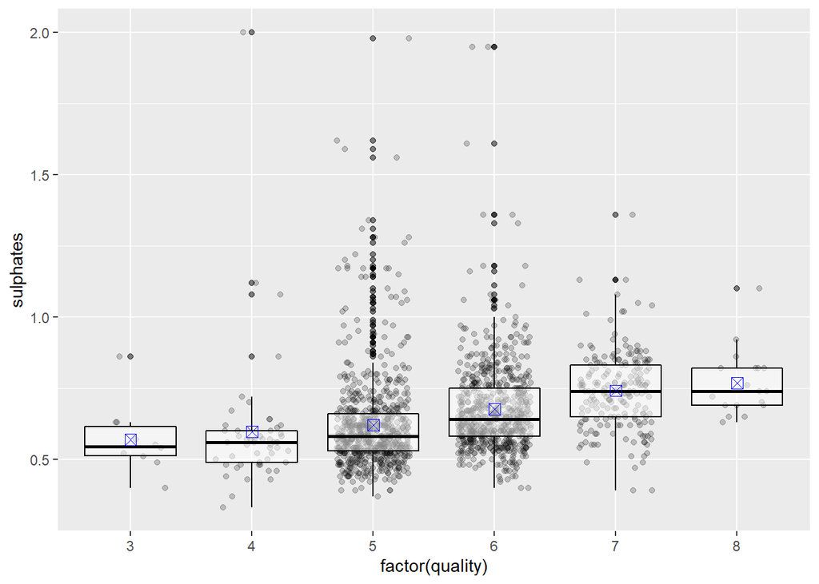

```
## Sulphates - Quality correlation:  0.251397079069261
```

> I have chosen this plot to identify if there is a relationship between the sulphate levels in a wine and its quality. I expected it would, as it affects the shelf-life and “freshness” of a wine.

> Sulphates have a moderate correlation with quality, at ~0.25. This makes sense, as the description of the sulphates feature indicates that it should improve the “freshness” of the wine. This is worth exploring further.

### pH-Quality relationships

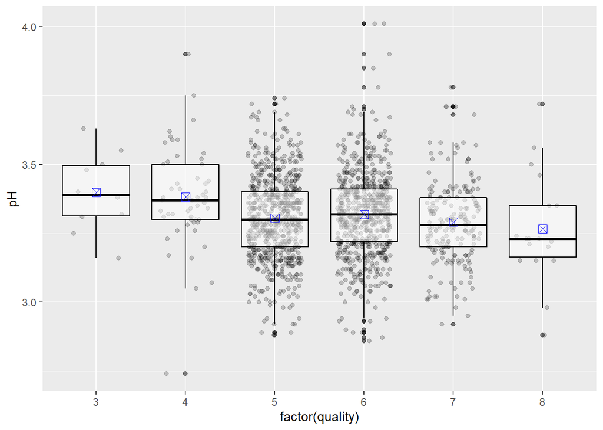

```
## pH - Quality correlation:  -0.0577313912053821
```

> I have chosen this plot to identify if there is a relationship between the acidity levels (acidity) in a wine and its quality. As the acidity of a wine is a strong aspect of its flavor, I expected that it would have a strong correlation.

> Acidity does not seem to be a strong predictor of quality, with a very weak negative correlation. This is surprising.

### Density-Quality relationships

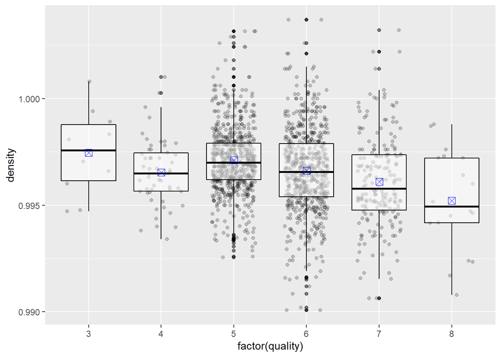

```
## Density - Quality correlation:  -0.174919227783349
```

> I have chosen this plot to identify if there is a relationship between the density of a wine and its quality. I suspected that it would, as the density of a wine affects its mouthfeel.

> There is a slight, but not insignificant, negative correlation between density and quality at ~-0.17.

### Chlorides-Quality relationships

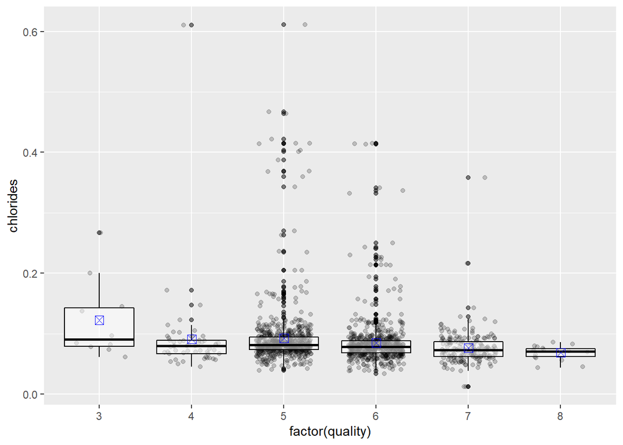

```
## Chlorides - Quality correlation:  -0.128906559930053
```

> I have chosen this plot to identify if there is a relationship between the chloride levels in a wine and its quality. A wine with a higher level of chlorides should be saltier, so I suspect that it should have some effect.

> Chlorides have a slight negative correlation with quality a ~-0.13. It would seem that saltier wines are less favorable.

## Inter-feature relationships

### Residual Sugar-Chlorides relationships

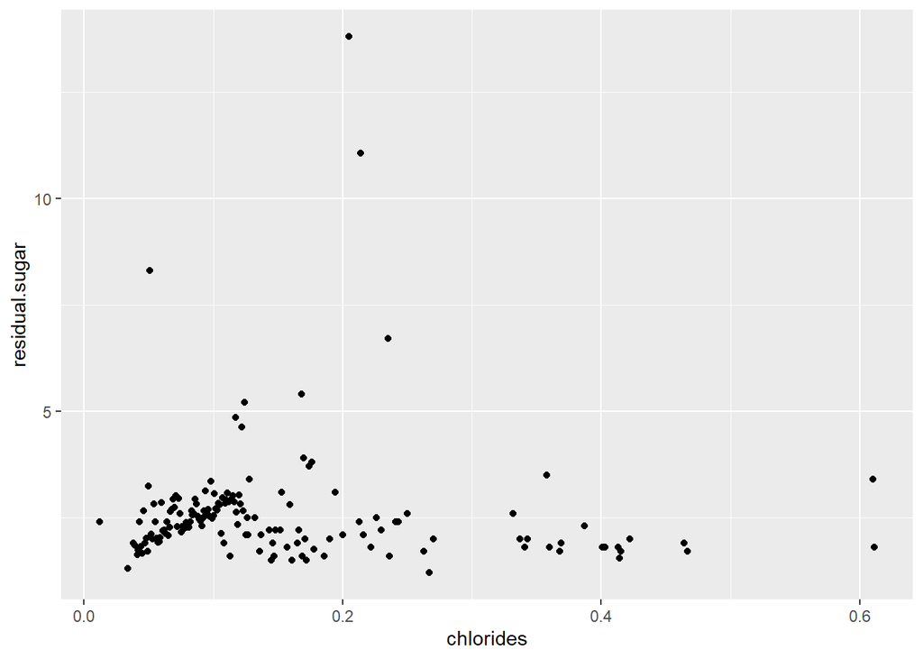

```
## Chlorides - Quality correlation:  0.0556095352035321
```

> Up to this point, I have only compared the relationships between chemical and physical properties of a wine with its quality. I have chosen this plot to identify if there is a relationship between residual sugars and chlorides.

> Residual Sugars and chlorides have a very weak correlation at ~0.06. As such, the presence of residual chlorides does not seem to have a significant impact on the presence of chlorides.

### Residual Sugar-Alcohol relationships

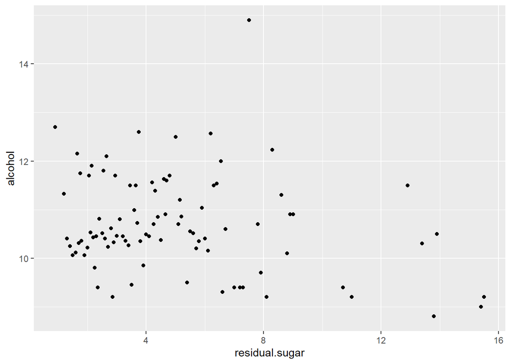

```
## Residual Sugar - Alcohol correlation:  0.0420754372097311
```

> I have chosen this plot to identify if there is a relationship between alcohol and residual sugars. I suspected there would be, as alcohol is a by-product of yeast consuming sugar.

> Residual sugars and alcohol have a very weak correlation at ~0.04. This, surprisingly, appears to be another dead-end.

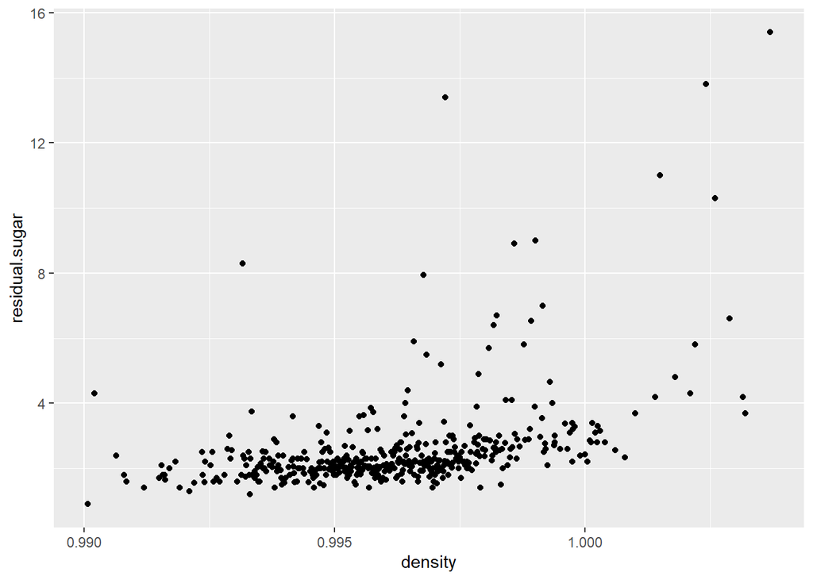

```
## Density - Residual Sugar correlation:  0.355283370983376
```

> I have chosen this plot to identify if there is a relationship between residual sugars and the density of a wine. I assumed there would be, as sugar is denser than water.

> Residual sguars and density have a moderate positive correlation at *~0.36!* This is the only significant correlation I have found between the interrelationships of the chemical and physical properties of a wine. I assume this has to do with the high relative density of sugar. If a wine contains more sugar leftover from the fermentation process, it will naturally be more dense. Even if this is only an observation of a physical property, it is still an interesting relationship to see.

# Bivariate Analysis

### Talk about some of the relationships you observed in this part of the investigation. How did the feature(s) of interest vary with other features in the dataset?

> The relationship between sulphates and quality was particularly interesting. While the average quality did increase with sulphate levels, it seems to cap off around 1.2. Levels higher than this result in scores averaging around 5.

> There was a negative relationship between the quality of wine and acidity. Less acidic wines seem to receive higher quality ratings.

> Density and chlorides also displayed a negative relationship with quality, with both saltier and denser wines performing worse on average.

### Did you observe any interesting relationships between the other features (not the main feature(s) of interest)?

> I did not find any significant relationships between other features. I compared residual sugars and chlorides, and found nothing of note.

> I did find it interesting that I did *not* find a significant relationship between residual sugars and alcohol content. I had expected lower residual sugar yielding a higher ABV wine, as the yeast would have consumed more of it. Since I did not find a relationship, I suspect the residual sugars may have more to do with the tolerance levels of the yeast strain used in brewing than in the total amount of sugar consumed by the yeast.

### What was the strongest relationship you found?

> The strongest relationship I found was by far the relationship between alcohol and quality. The correlation between alcohol and quality was *~0.48*. This was almost twice as strong of a correlation as the second strongest, which was sulphates and quality at a correlation of ~0.25.

# Multivariate Plots Section

> The three strongest factors in the quality of a wine were its alcohol, density, and sulphates. As such, I would like to test the relationships between these three factors and their effect on quality.

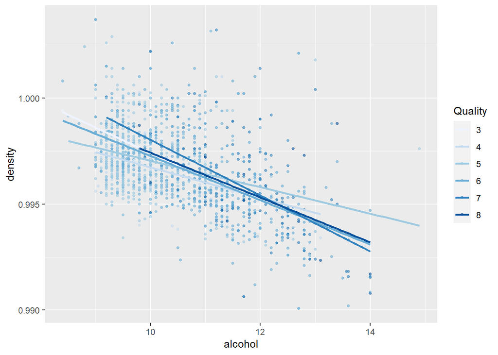

> Here, we can clearly see the relationship between quality and alcohol, but the relationship between density and quality is not immediately apparent.

> This may be indicative that the relationship between quality and density is overshadowed by the strength of the relationship between quality and alcohol. There does not appear to be a synergistic relationship between the two features, or, if there is, then it is very weak.

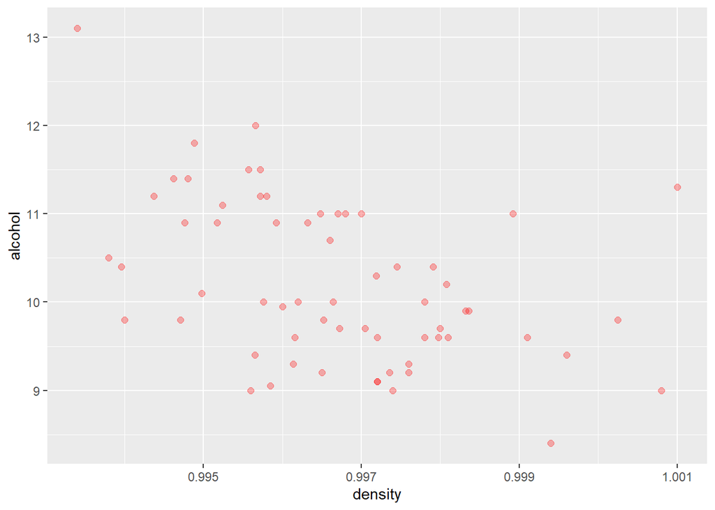

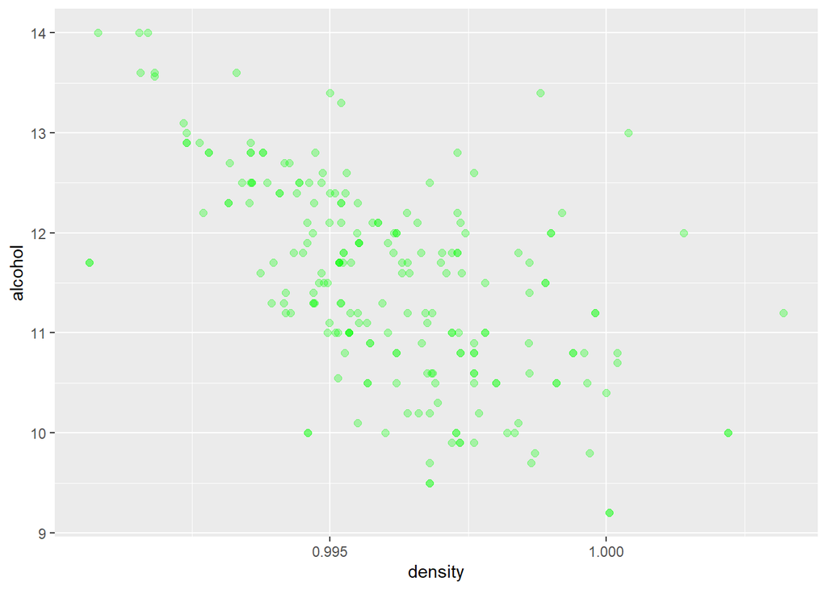

> Here, we have isolated “high quality” wines (those scoring greater than 6). These points appear similarly random compared to the low quality wines. This appears to be a dead-end. I will stick to my original hypothesis that density and alcohol do not have a synergistic relationship.

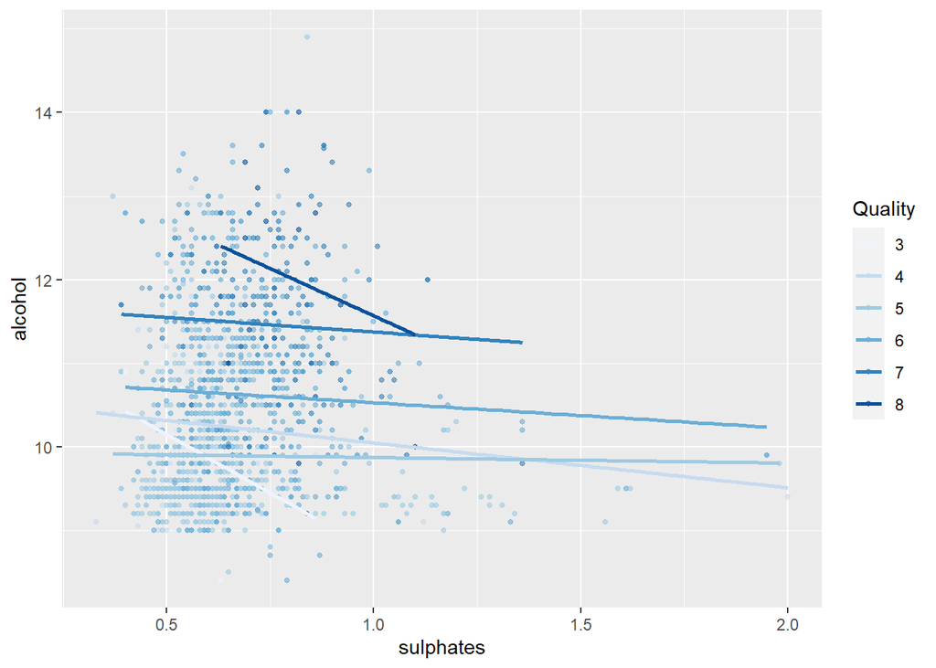

> This is a much stronger relationship. We can see a cluster of low quality wines where alcohol is under 10% and sulphate levels are less than 0.8.

> “Medium” quality wines begin to cluster around the middle of the group. showing that wines with greater than 10% abv with sulphate levels greater than 0.6 or so are given average ratings.

> High quality wines begin to cluster where alcohol levels surpass 12% and sulphates are at least 0.7.

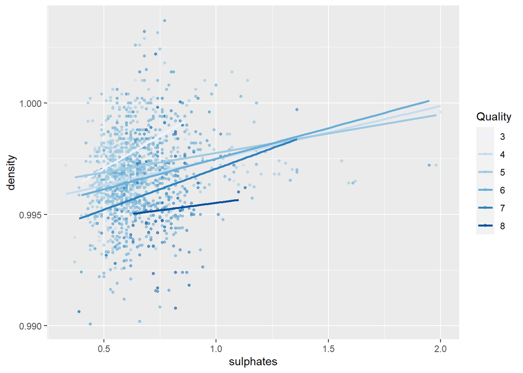

> Again, we do not see a strong synergy between density and sulphates. I suspect separating high and low quality wines will yield a similar result to alcohol and density.

# Multivariate Analysis

### Talk about some of the relationships you observed in this part of the investigation. Were there features that strengthened each other in terms of looking at your feature(s) of interest?’

> The very best performing wines were high-alcohol, high-sulphates, while the very worst performing wines were low-alcohol, low-sulphates.

### Were there any interesting or surprising interactions between features?

> It was surprising to see how small a role density played in the quality of a wine after alcohol content and sulphates are taken into account. By itself, density had a correlation with quality of *~-0.175*. While this is not a significant number, it is completely overpowered by alcohol and sulphates.

# Final Plots and Summary

> **Tip**: You’ve done a lot of exploration and have built up an understanding of the structure of and relationships between the variables in your dataset. Here, you will select three plots from all of your previous exploration to present here as a summary of some of your most interesting findings. Make sure that you have refined your selected plots for good titling, axis labels (with units), and good aesthetic choices (e.g. color, transparency). After each plot, make sure you justify why you chose each plot by describing what it shows.

### Plot One

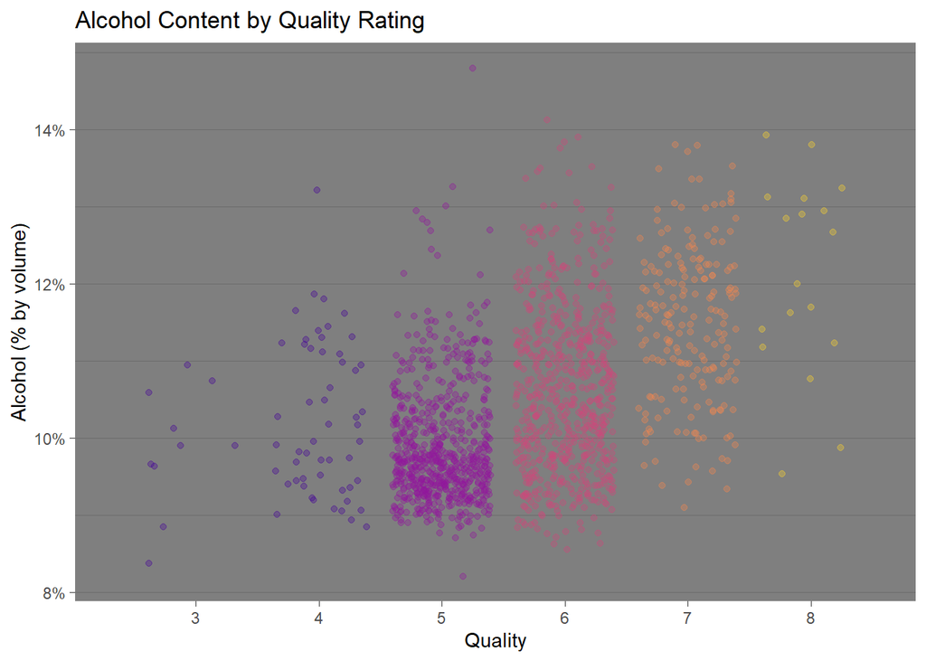

### Description One

> Here, we can see both the distribution of quality ratings along the x-axis, as well as the quality rating of wines based on their alcohol percent. We can see that most wines received ratings of 5 or 6, and that the highest rated wines are only found at higher alcohol percentages.

> We can also see the inverse relationship, in that the worst rated wines are overwhelmingly found in weaker wines.

> Wines between 9% and 10% represent the majority of wines that received a quality rating of 5, whereas wines that received a quality rating of 6 have a much larger variance in their alcohol content.

### Plot Two

[figure not shown]

### Plot Three

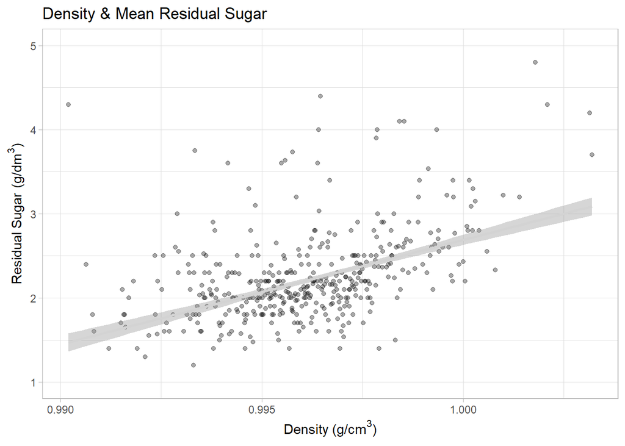

### Description Three

> I selected this chart because it showed the strongest relationship between two non-main features of interest. There is a clear positive relationship between residual sugars and density. There is a moderate correlation at ~0.36.

> As there are many wines with the same density, only the mean residual sugar is shown for each point of density.

> As sugar is more dense than water, this graph demonstrates how the density increases with every bit of sugar that has not been metabolized by the yeast. As such, residual sugars do not only affect the sweetness of a wine, but indirectly affect the density, and, as such, the mouthfeel of the wine.

# Reflection

> I was surprised that residual sugars did not have a stronger effect on the quality of wines, with a correlation of only ~0.014. I had imagined that higher residual sugars would result in a sweeter wine, which would affect the quality in some capacity. After further thought, I believe that wines may have been rated on their expected sweetness based on the type of wine they represent. If a wine is expected to be dry, a low residual sugar level should not negatively impact its quality. This would mean that the residual sugars alone should not heavily impact wine quality.

> My greatest difficulty was trying to find relationships between the physical and chemical features. While most features influenced quality to some degree, there was very little relationship amongst the features themselves. I was only able to find a moderate correlation between residual sugars and density. While this does explain an expected relationship, it does not provide much predictive insight. I wish I had been able to find a stronger relationship, but this may be the strongest that is readily discoverable.

> I have mostly only performed descriptive statistics and visualization in this report. If I had more time, I would like to have performed more inferential statistics. Ideally, I would like to have implemented rigorous mathematical models and performed predictive analysis to see if I could predict the quality rating of a wine based on inputs of its physical and chemical properties.